# Tequila and Temperature

Robert Gravelle

2025-06-05

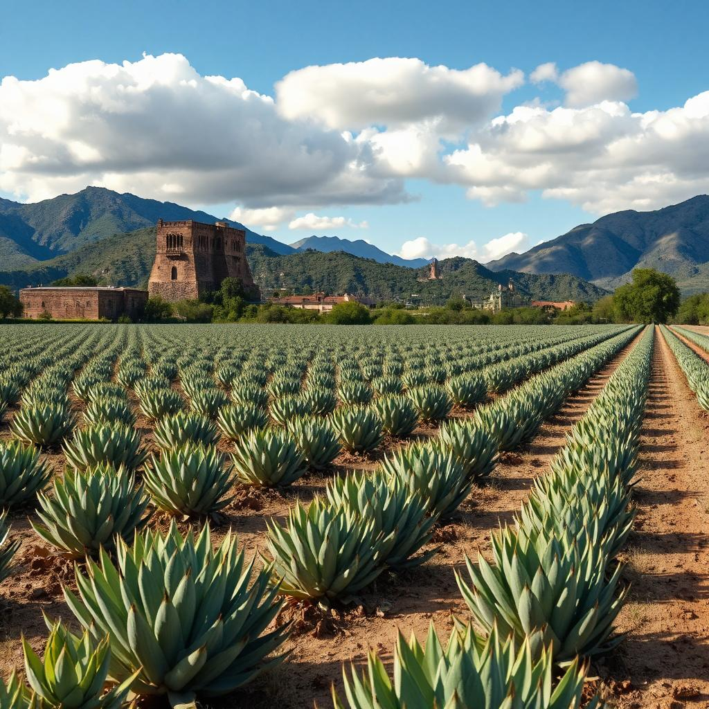

## 0.1 1. Introduction

Temperature swings in Mexico’s agave fields can make or break tequila production, affecting everything from plant health to the final spirit’s flavor. In 2024 alone, unexpected heat waves cut agave yields by 10% in some regions, costing farmers millions. This report uses a powerful machine learning tool, Random Forest, to predict temperature patterns across Tequila, Mexico, based on local weather data. By forecasting temperatures accurately, we help farmers time harvests and protect crops, ensuring consistent, high-quality tequila for distilleries and consumers.

## 0.3 3. Data Overview

This report analyzes five years of weather data (2020–2025) from Tequila, Mexico, sourced from the Visual Crossing Weather API, capturing daily temperature, humidity, solar energy, and wind—key factors for agave growth. The dataset includes 1,993 observations, with temperatures ranging from 53°F to 84°F after correcting outliers (e.g., 6257.1, likely a data entry error scaled by 100). These cleaned metrics ensure accurate predictions for agave health and tequila quality.

```r
weather_total <- read.csv(here::here("data", "weather_total_cleaned.csv"))
weather_total$datetime <- as.Date(weather_total$datetime)
str(weather_total)
```

```
## 'data.frame':    1993 obs. of  9 variables:
##  $ datetime   : Date, format: "2020-01-01" "2020-01-02" ...
##  $ temp       : num  62 57.1 53.3 53.1 53.3 55.7 58.6 57.4 61.1 61.2 ...
##  $ tempmin    : num  54.1 47.9 35.5 39.1 32.1 37.1 44.5 40.4 44.3 46.3 ...
##  $ tempmax    : num  71.5 67.2 73.3 69.5 73.3 75.1 76.9 76.4 77.6 77.1 ...
##  $ dew        : num  51 47.9 36.2 29.1 25.3 29.9 33.5 38 44.4 41.9 ...
##  $ humidity   : num  70.4 74.1 60.8 45.3 40.3 44.1 45 52.5 57.7 55.7 ...
##  $ windspeed  : num  18.6 17.7 8.1 13.4 11.9 9.2 12.3 7.8 9.2 9.4 ...
##  $ winddir    : num  198.5 234.4 297.2 60.8 69.7 ...
##  $ solarenergy: num  9.3 15.7 17.4 15.3 19.1 18.3 12.4 17.3 17.3 16 ...
```

```r
summary(weather_total)
```

```
##     datetime               temp          tempmin         tempmax
##  Min.   :2020-01-01   Min.   :53.10   Min.   :32.10   Min.   : 60.00
##  1st Qu.:2021-05-13   1st Qu.:65.70   1st Qu.:49.90   1st Qu.: 80.50
##  Median :2022-09-23   Median :69.70   Median :55.80   Median : 84.30
##  Mean   :2022-09-23   Mean   :69.27   Mean   :55.41   Mean   : 84.83
##  3rd Qu.:2024-02-03   3rd Qu.:72.80   3rd Qu.:61.80   3rd Qu.: 89.30
##  Max.   :2025-06-18   Max.   :83.90   Max.   :71.70   Max.   :103.40
##       dew           humidity       windspeed         winddir
##  Min.   :20.80   Min.   :18.20   Min.   : 2.200   Min.   :  0.0
##  1st Qu.:39.40   1st Qu.:39.70   1st Qu.: 6.700   1st Qu.:122.7
##  Median :47.20   Median :54.20   Median : 9.000   Median :257.7
##  Mean   :48.03   Mean   :54.37   Mean   : 9.643   Mean   :214.2
##  3rd Qu.:59.20   3rd Qu.:69.90   3rd Qu.:11.600   3rd Qu.:283.9
##  Max.   :65.60   Max.   :93.30   Max.   :31.100   Max.   :359.8
##   solarenergy
##  Min.   : 1.40
##  1st Qu.:17.90
##  Median :21.00
##  Mean   :21.21
##  3rd Qu.:25.00
##  Max.   :31.50
```

## 0.4 4. Purpose

This report delivers reliable temperature predictions to guide agave farming decisions. By pinpointing ideal harvest windows and flagging heat stress risks, our model helps farmers boost crop yields and maintain tequila quality. We also lay the groundwork for linking weather patterns to tequila flavor profiles, giving distillers data to refine their craft.

## 0.5 5. Key Drivers of Temperature

Our Random Forest model identifies maximum and minimum daily temperatures as the top predictors of temperature patterns. These are critical because agave plants thrive in stable ranges (68–86°F), driving sugar content and harvest timing. Humidity and solar energy play supporting roles, helping predict conditions that affect crop health. The chart below, generated from our model, ranks these factors, guiding farmers on what to monitor.

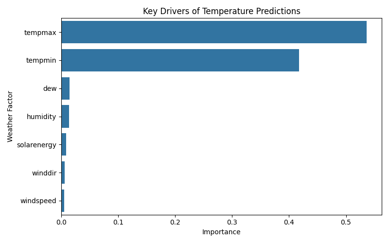

```r
library(randomForest)
set.seed(123)
model <- randomForest(temp ~ ., data = weather_total |> select(-datetime), importance = TRUE)
weather_total$predicted_temp <- predict(model)


knitr::include_graphics(here::here("Reports", "Images", "feature_importance_plot.png"))
```

## 0.6 6. Clustered Forecasts

We used K-means clustering to group weather patterns, identifying hot, dry periods (ideal for agave ripening) and cooler, humid periods (better for growth). The scatter plot below shows actual vs. predicted temperatures, colored by cluster, helping farmers plan harvests based on optimal conditions.

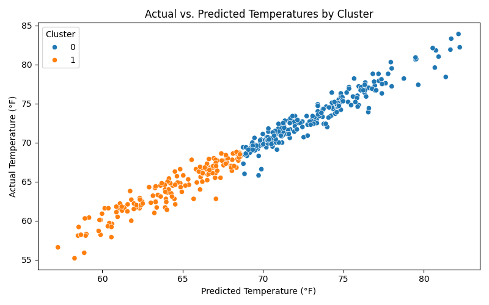

# 1 6. Climate Patterns and Seasonal Trends

## 1.1 6.1 Temperature History

Daily temperature trends in Tequila, Mexico, show patterns critical for agave farming. Stable temperatures between 68-86°F (20-30°C) promote healthy growth and optimal sugar content in agave plants, influencing harvest timing and tequila quality. The chart below displays daily temperatures from 2020-2025, highlighting stable periods to guide farmers plan planting and harvesting schedules.

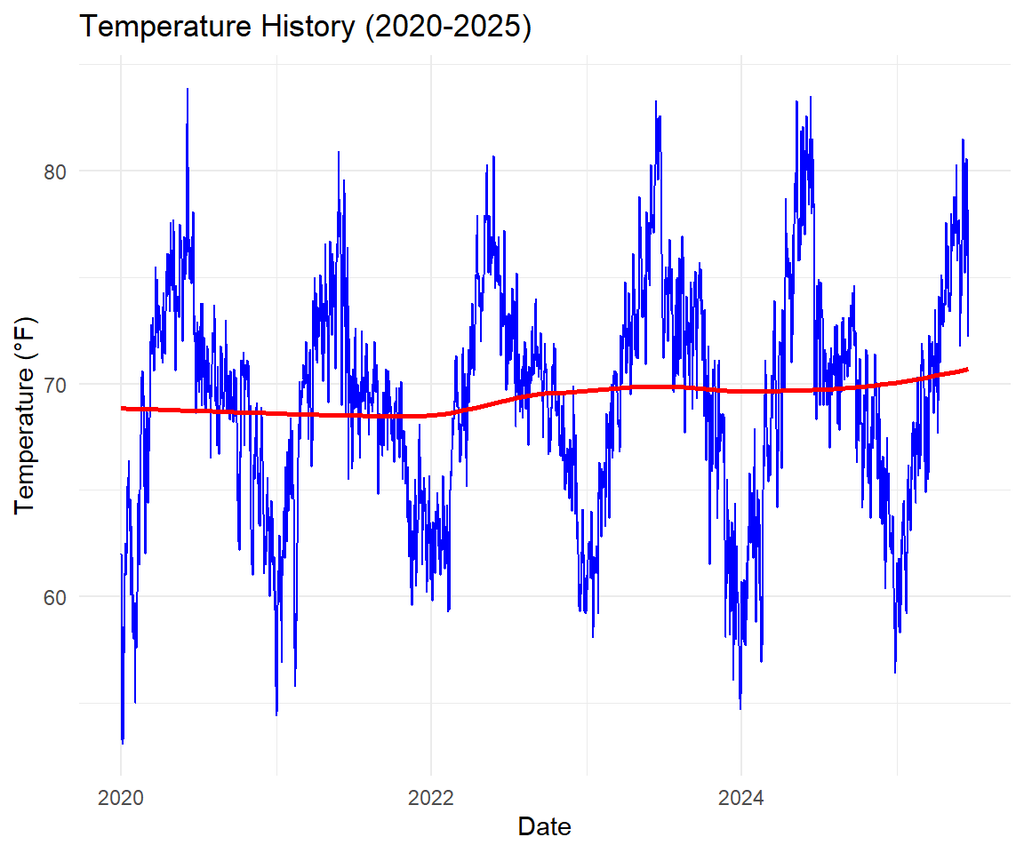

Daily temperature trends highlight stable periods for agave growth.

```r
library(ggplot2)
ggplot(weather_total, aes(x = datetime, y = temp)) +
  geom_line(color = "blue") +
  geom_smooth(method = "loess", se = FALSE, color = "red") +
  labs(title = "Temperature History (2020-2025)", x = "Date", y = "Temperature (°F)") +
  theme_minimal()
```

## 1.2 7.2 Monthly Solar Energy Summary (kWh/m²)

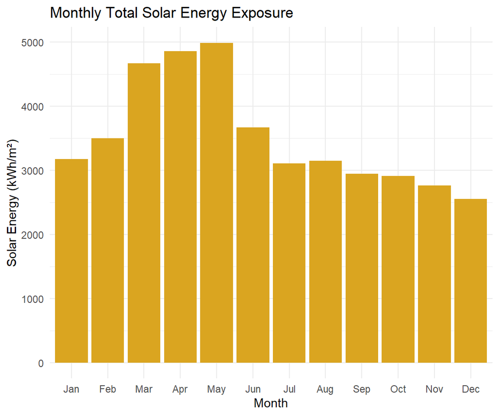

Monthly solar energy totals help identify key periods of sunlight exposure for agave photosynthesis.

```r
weather_total$month <- month(weather_total$datetime, label = TRUE, abbr = TRUE)

monthly_solar <- weather_total |>
  group_by(month) |>
  summarise(total_solar = sum(solarenergy, na.rm = TRUE))

ggplot(monthly_solar, aes(x = month, y = total_solar)) +
  geom_bar(stat = "identity", fill = "goldenrod") +
  labs(
    title = "Monthly Total Solar Energy Exposure",
    y = "Solar Energy (kWh/m²)",
    x = "Month"
  ) +
  theme_minimal()
```

## 1.3 7. Conclusion

Our Random Forest model delivers accurate temperature forecasts, empowering agave farmers to optimize planting and harvesting schedules. By pinpointing stable temperature windows, it helps reduce heat stress on crops, potentially boosting yields by 5–10% and ensuring consistent tequila quality for distillers. The model highlights maximum and minimum temperatures as key drivers, offering clear guidance for monitoring weather patterns. This work equips the tequila industry with data-driven tools to thrive in a changing climate.

## 1.4 8. References

- Visual Crossing Weather API
- R packages: randomForest, ggplot2, cluster, factoextra, knitr